# Advisor choice (dates)

[Matt Jaquiery](https://github.com/mjaquiery) (matt.jaquiery@psy.ox.ac.uk)

May 2020

[Script run 2020-05-13 18:15:15]

# Introduction

We have [previously observed](https://oxacclab.github.io/ExploringSocialMetacognition/analysis/ACv2/writeUp_v1.0.1.html) that people are more influenced by accurate over agreeing advisors when given feedback, and by agreeing over accurate advisors when denied feedback. Here we seek to extend that finding to the domain of source selection by offering participants a choice of advisor.

## Preregistration

This is a preregistered replication of a [previous study](https://oxacclab.github.io/ExploringSocialMetacognition/analysis/ACv2/advisorChoice_v0.0.6.html) which demonstrated that people would preferentially pick the Accurate advisor when provided with feedback. When feedback was withheld, the evidence suggested the rates of picking were equivalent to chance (although very noisy). The preregistration is done via the OSF, and, because the OSF is having some issues at the moment, via AsPredicted.org.

## Bayes stats

The Bayesian stats presented below use default priors. These are no more wildly unsuitable than frequentist t-test assumptions (also provided), but the competing models of selection can be specified more precisely and compared more directly. This analysis will be added at a later date.

# Method

Participants are trained on an estimation decision task (dates task) and familiarised with two advisors within a judge-advisor system, one of who offers advisory estimates close to the participant’s initial estimate (‘agreeing advisor’) and one who offers advisory estimates close to the true answer (‘accurate advisor’). In the test phase, participants are allowed to choose which of the two advisors will give them advice on each trial.

The experimental code is available on [GitHub](https://github.com/oxacclab/ExploringSocialMetacognition), and the experiment can be performed by visiting [https://acclab.psy.ox.ac.uk/~mj221/ESM/ACv2/ac.html](https://acclab.psy.ox.ac.uk/~mj221/ESM/ACv2/ac.html?PROLIFIC_PID=WriteUp).

# Results

## Exclusions

```
##
##                                       Feedback.AgreeFirst
##   adviceColumnsNumeric                                  1
##   adviceColumnsNumeric eightKeyTrials                   1
##   badMarker                                             0
##   badMarker eightKeyTrials                              0
##   eightKeyTrials                                        2
##   FALSE                                                 8
##   outlyingTrials                                        2
##
##                                       Feedback.AccurateFirst
##   adviceColumnsNumeric                                     0
##   adviceColumnsNumeric eightKeyTrials                      0
##   badMarker                                                0
##   badMarker eightKeyTrials                                 1
##   eightKeyTrials                                           0
##   FALSE                                                   10
##   outlyingTrials                                           1
##
##                                       Nofeedback.AgreeFirst
##   adviceColumnsNumeric                                    0
##   adviceColumnsNumeric eightKeyTrials                     0
##   badMarker                                               0
##   badMarker eightKeyTrials                                1
##   eightKeyTrials                                          2
##   FALSE                                                   7
##   outlyingTrials                                          1
##
##                                       Nofeedback.AccurateFirst
##   adviceColumnsNumeric                                       0
##   adviceColumnsNumeric eightKeyTrials                        1
##   badMarker                                                  1
##   badMarker eightKeyTrials                                   0
##   eightKeyTrials                                             3
##   FALSE                                                      7
##   outlyingTrials                                             0
```

Our final participant list consists of 32 participants who completed an average of 37.41 trials each. There were 18 participants in the Feedback condition, and 14 in the No feedback condition.

## Task performance

First we offer a characterisation of the task, to provide the reader with a sense of how the participants performed.

### Decisions

Participants offered estimates of whether various events took place before or after a given year. The correct answers were always between 1900 and 2000. Participants answered selecting a marker from a pool of available markers and dragging it onto a timeline to cover a range of dates within which they thought the event took place.

#### Correctness

Correct answers are those in which the chosen marker covers the year in which the event took place.

| decision | mean | CL95.Low | CL95.High | Phase |
| --- | --- | --- | --- | --- |
| first | .433 | .371 | .494 | Familiarization |
| last | .585 | .527 | .643 | Familiarization |
| Overall | .509 | .453 | .565 | Familiarization |

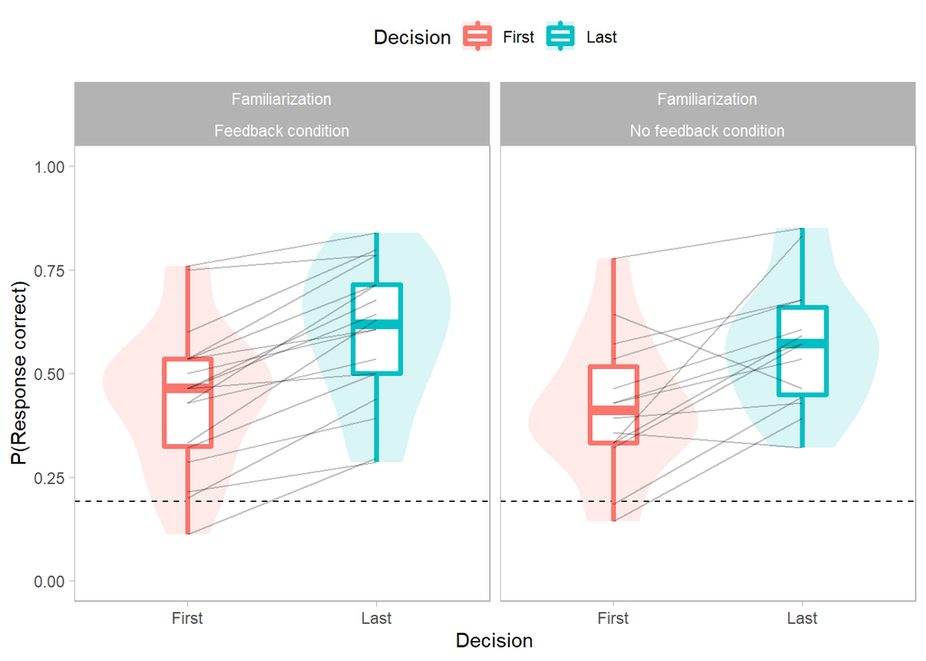

### Error

Error is the distance in years between the centre of the marker and the correct year. Note that when using smaller markers it is possible for answers to be incorrect (the marker doesn’t cover the correct year) while still having relatively low error (the centre of the marker is close to the correct year).

| decision | mean | CL95.Low | CL95.High | Phase |
| --- | --- | --- | --- | --- |
| first | 21.5 | 19.6 | 23.3 | Familiarization |
| last | 17.8 | 16.4 | 19.2 | Familiarization |
| Overall | 19.6 | 18.2 | 21.1 | Familiarization |

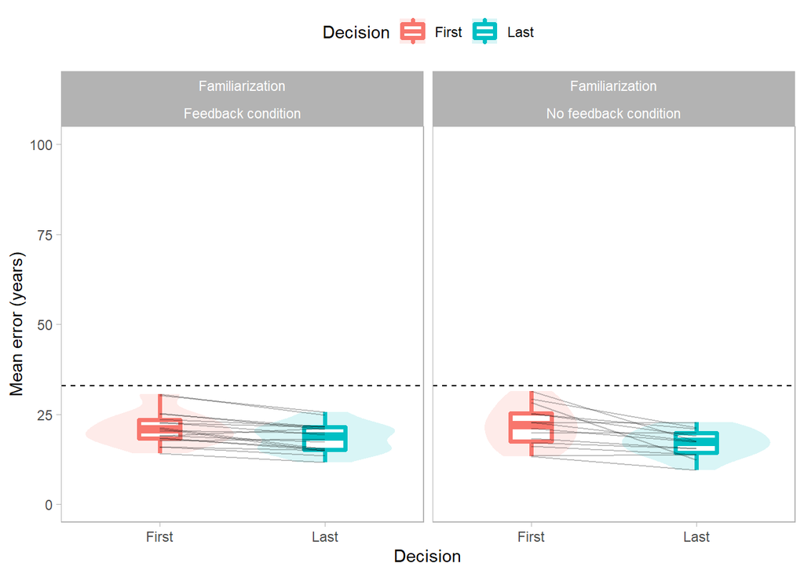

### Timing

We can look at the response time - the difference between the time the response is opened and the time the response is received.

| decision | mean | CL95.Low | CL95.High | Phase |
| --- | --- | --- | --- | --- |
| first | 10185 | 8666 | 11705 | Familiarization |
| last | 5382 | 4648 | 6115 | Familiarization |
| Overall | 7783 | 6922 | 8645 | Familiarization |

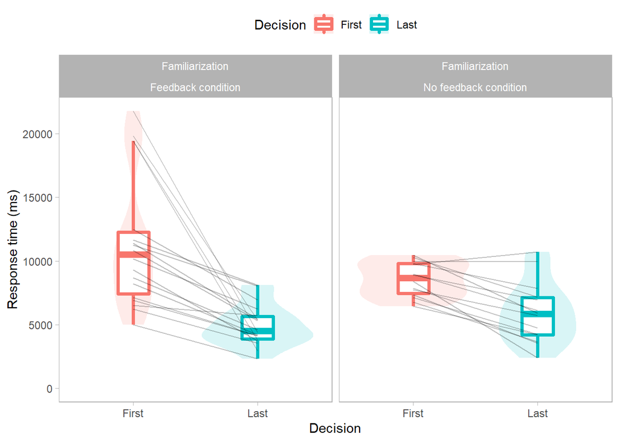

### Summary

Participants performed the task as expected: responses were better than chance, and almost all participants increased their response accuracy from initial estimates to final decisions. Likewise, error was lower than would be expected with random marker placement, and errros decreased from initial estimate to final decision. Participants took several seconds to make each decision, around 10s for initial estimates and 5s for final decisions. *NB:* they had seen the advice for 2s by the time the final decision window started.

## Metacognitive performance

### Marker usage

Participants could select one of three markers, each spanning a different number of years. They were awarded more points for selecting slimmer markers.

| decision | feedback | mean\|m=13 | mean\|m=7 | mean\|m=21 |
| --- | --- | --- | --- | --- |
| first | FALSE | .352 | .140 | .508 |
| first | TRUE | .513 | .153 | .334 |
| first | NA | .442 | .147 | .410 |

| decision | feedback | mean\|m=13 | mean\|m=7 | mean\|m=21 |
| --- | --- | --- | --- | --- |
| last | FALSE | .386 | .294 | .319 |
| last | TRUE | .515 | .179 | .306 |
| last | NA | .459 | .229 | .312 |

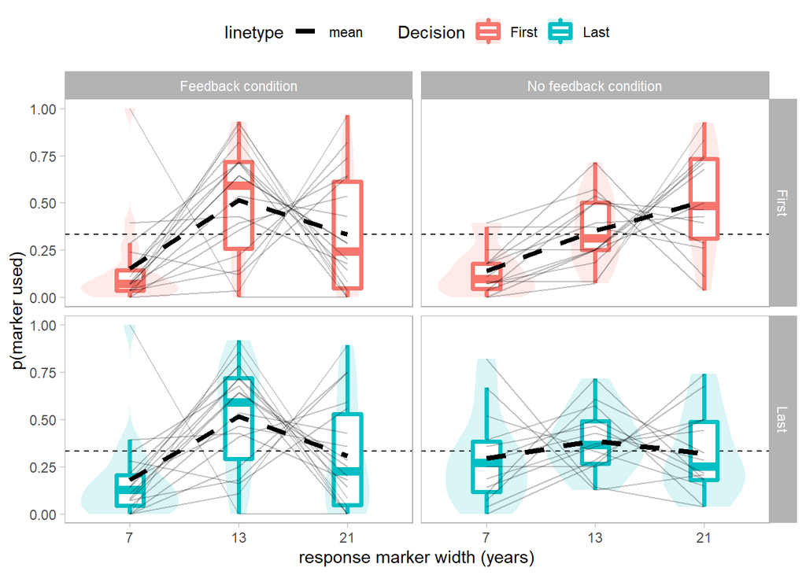

#### Feedback condition by advisor

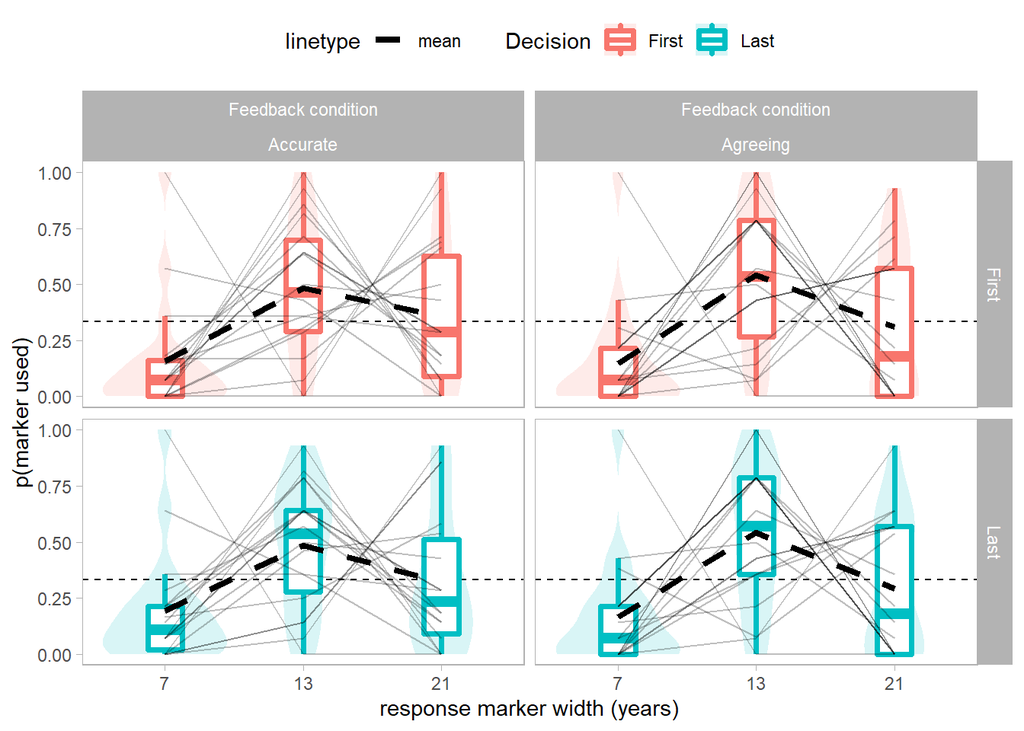

### Relationship between marker width and error

Participants indicated the confidence in their decisions simultaneously with the decisions themselves through their choice of which marker to use. We can thus explore how well a participant’s confidence signals their accuracy. We expect that slimmer markers will be associated with less error.

| decision | feedback | mean\|m=13 | mean\|m=7 | mean\|m=21 | mean |
| --- | --- | --- | --- | --- | --- |
| first | FALSE | 15.4 | 12.2 | 27.9 | 21.8 |
| first | TRUE | 19.9 | 10.7 | 27.0 | 21.2 |
| first | NA | 17.8 | 11.4 | 27.4 | 21.5 |

| decision | feedback | mean\|m=13 | mean\|m=7 | mean\|m=21 | mean |
| --- | --- | --- | --- | --- | --- |
| last | FALSE | 16.0 | 10.3 | 23.4 | 16.9 |
| last | TRUE | 17.7 | 8.3 | 23.4 | 18.5 |
| last | NA | 16.9 | 9.3 | 23.4 | 17.8 |

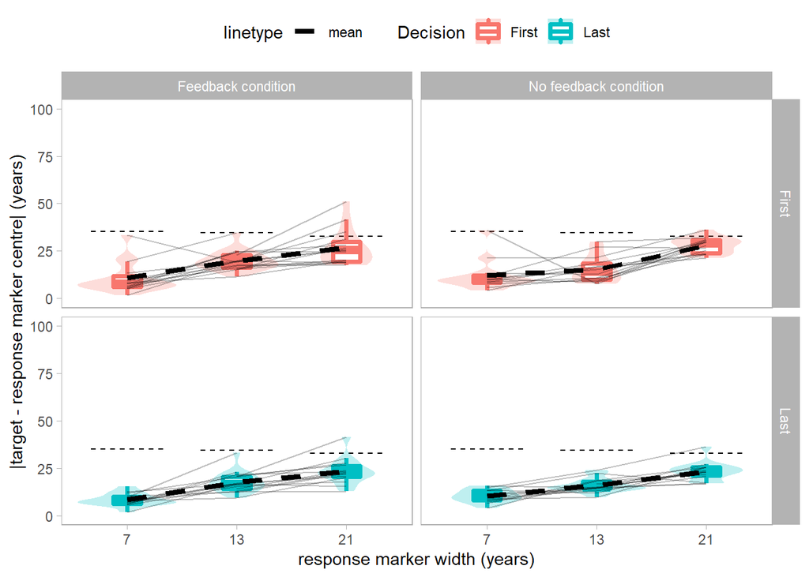

### Summary

Participants in the Feedback condition favoured the middle-width marker at the expense of the narrowest marker for both initial and final decisions. Participants in the No feedback condition preferred the widest marker at the expense of the narrowest for initial decisions, but were roughly equally likely to use any marker width for final decisions. Participants in the Feedback condition did not seem to alter their marker choice as a function of the advisor providing them with advice. There was a good deal of interpersonal variation in marker usage in all groups, although it is probable that individual participants were reasonably consistent with their marker choices.

Participants had lower error on average for thinner markers, indicating appropriate usage of markers according to the accuracy of the participant’s knowledge of the answer.

## Advisor performance

Participants in should get an appropriate experience of each advisor during familiarisation. The accurate advisor should have low error, while the agreeing advisor should have low distance (a measure of the distance between the centre of the advice and the participant’s initial estimate).

### Error

| advisor0idDescription | FeedbackCondition | adviceError | adviceDistance |
| --- | --- | --- | --- |
| Accurate | Feedback condition | 5.349 | 19.199 |
| Accurate | No feedback condition | 5.261 | 18.899 |
| Agreeing | Feedback condition | 15.506 | 8.812 |
| Agreeing | No feedback condition | 15.593 | 8.662 |

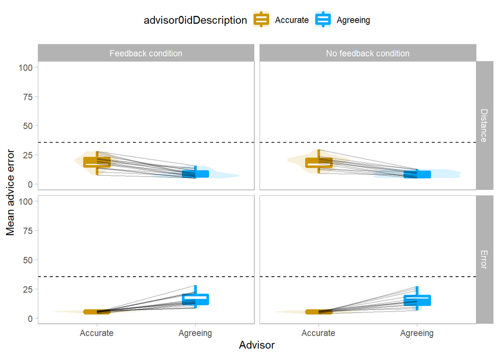

### Summary

As planned, the advisors’ advice differed. The Accurate advisor had lower error than the Agreeing advisor, and the distance between the participant’s initial estimate and the advisor’s marker was lower for the Agreeing advisor than the Accurate advisor. This need not by the case by definition (they will be equivalent if the participant is perfectly accurate), but are expected for any reasonable level of participant (in)accuracy.

## Advice during Familiarization

The participants had a familiarization block with each of the advisors individually. While these blocks are relatively short, learning may be rapid enough to demonstrate differences in influence.

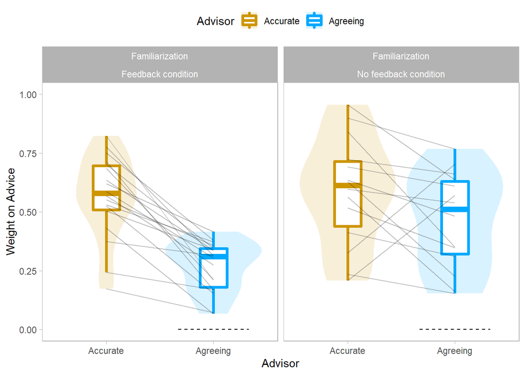

We included a couple of trials in each familiarization block where the advisors gave matched advice. We can compare influence just on those trials.

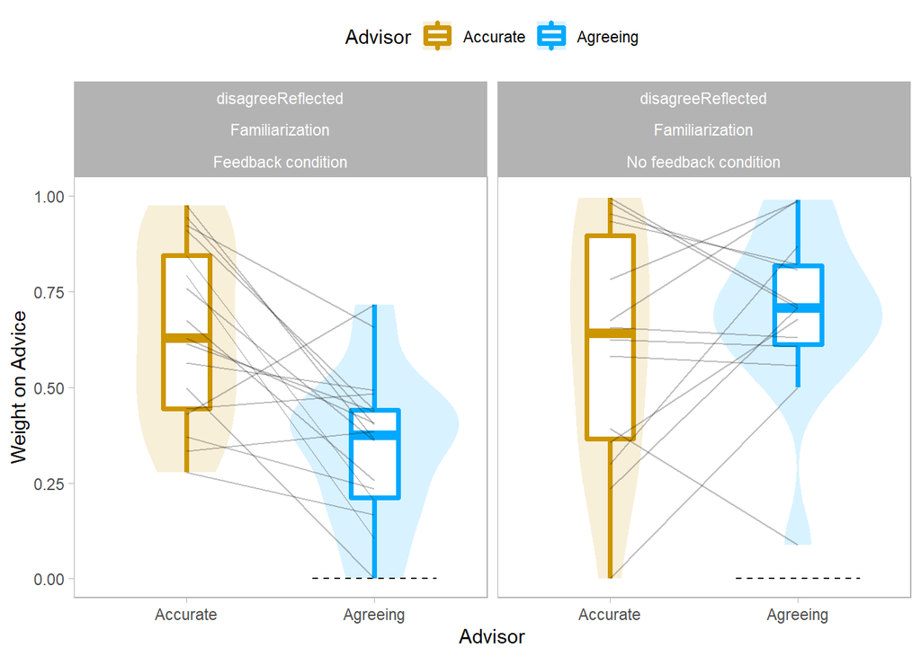

### Summary

Participants’ weight on advice for the disagreeReflected (off brand) trials formed the primary outcome measure of [a previous study](https://oxacclab.github.io/ExploringSocialMetacognition/analysis/ACv2/writeUp_v1.0.1.html). Here we do not observe as striking a pattern of greater influence of Accurate advisors in the Feedback condition and of Agreeing advisors in the No feedback condition. We do, however, observe a greater influence of Accurate advisors in the Feedback condition, and it is plausible there is slightly greater influence for the Agreeing advisor in the No feedback condition.

## Hypothesis testing

The hypotheses being tested here are:

1. Participants’ pick rates for the two advisors will differ by condition.
2. Participants in the Feedback condition will pick the Accurate advisor more than the Agreeing advisor.
3. Participants in the No feedback condition will pick the Agreeing advisor more than the Accurate advisor.

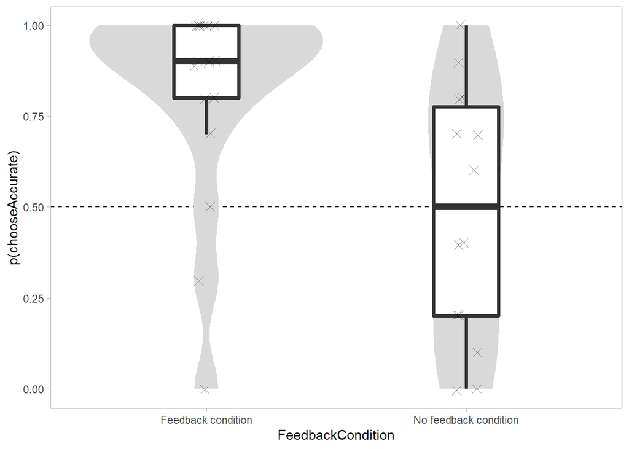

```
## Bayes factor analysis
## --------------
## [1] Alt., r=0.707 : 7.444708 ±0%
##
## Against denominator:
##   Null, mu1-mu2 = 0
## ---
## Bayes factor type: BFindepSample, JZS
```

```
## Bayes factor analysis
## --------------
## [1] Alt., r=0.707 : 158.6361 ±0%
##
## Against denominator:
##   Null, mu = 0.5
## ---
## Bayes factor type: BFoneSample, JZS
```

```
## Bayes factor analysis
## --------------
## [1] Alt., r=0.707 : 0.2728184 ±0.01%
##
## Against denominator:
##   Null, mu = 0.5
## ---
## Bayes factor type: BFoneSample, JZS
```

### Summary

The participants’ advisor pick rate differed according to whether the participants were in the Feedback or No feedback condition. Those in the Feedback condition showed a strong preference for the Accurate advisor. Those in the No feedback condition showed no systematic preference.

## Exploration

### Influence during Familiarization x Pick preference

For influence we use the disagreeReflected trials only.

```
## [1] ">> Feedback condition (disagreeReflected trials only)"
```

```
##
##  Pearson's product-moment correlation
##
## data:  n and woa
## t = -1.2945, df = 15, p-value = 0.2151
## alternative hypothesis: true correlation is not equal to 0
## 95 percent confidence interval:
##  -0.6921772  0.1930673
## sample estimates:
##        cor
## -0.3169934
```

```
## [1] ">> No feedback condition (disagreeReflected trials only)"
```

```
##
##  Pearson's product-moment correlation
##
## data:  n and woa
## t = 3.1505, df = 12, p-value = 0.008367
## alternative hypothesis: true correlation is not equal to 0
## 95 percent confidence interval:
##  0.2212274 0.8868231
## sample estimates:
##       cor
## 0.6728309
```

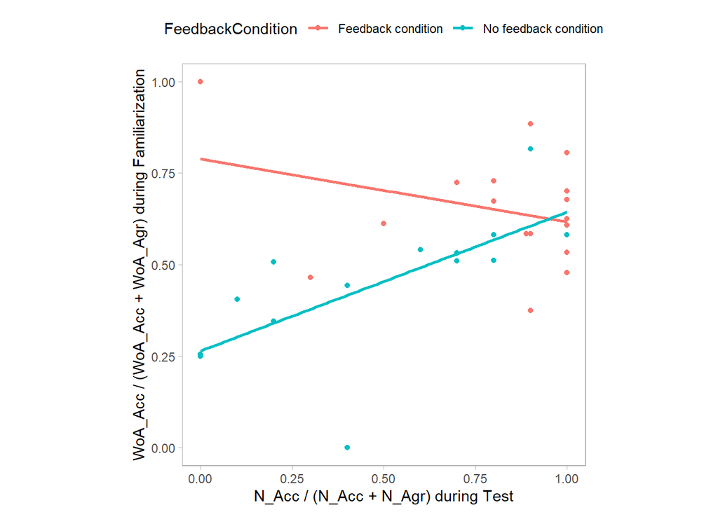

### Advisor ratings

We can look at the questionnaire items for the advisors, too.

| pid | knowledge | helpfulness | likability | comment | advisorId | FeedbackCondition | woa | n | idDescription |
| --- | --- | --- | --- | --- | --- | --- | --- | --- | --- |
| d28d0cf1 | 74 | 90 | 91 |  | 1 | No feedback condition | 0.5413534 | 0.6000000 | Accurate |
| d28d0cf1 | 95 | 98 | 100 |  | 2 | No feedback condition | 0.5413534 | 0.6000000 | Agreeing |
| 27958e21 | 84 | 85 | 82 | This advisor was pretty accuraccurate on many of the questions | 1 | Feedback condition | 0.6778996 | 1.0000000 | Accurate |
| 27958e21 | 32 | 37 | 34 | This Advisor was off on some of the questions | 2 | Feedback condition | 0.6778996 | 1.0000000 | Agreeing |
| 1da43186 | 21 | 32 | 36 | Looks like a fake advisor. | 2 | No feedback condition | 0.5104167 | 0.7000000 | Agreeing |
| 1da43186 | 70 | 72 | 74 | Better but not a perfect advisor. | 1 | No feedback condition | 0.5104167 | 0.7000000 | Accurate |
| 7e145756 | 85 | 72 | 50 |  | 2 | No feedback condition | 0.2489154 | 0.0000000 | Agreeing |
| 7e145756 | 20 | 36 | 50 |  | 1 | No feedback condition | 0.2489154 | 0.0000000 | Accurate |
| dac2303f | 57 | 45 | 50 |  | 1 | Feedback condition | 0.6738347 | 0.8000000 | Accurate |
| dac2303f | 45 | 41 | 52 |  | 2 | Feedback condition | 0.6738347 | 0.8000000 | Agreeing |

[output cut: 54 more lines]

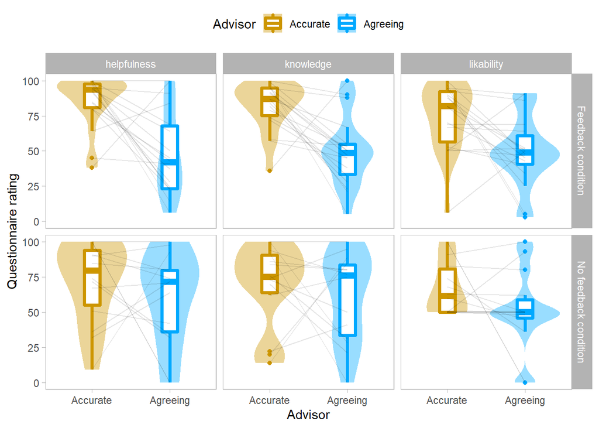

[output not shown]

| name | FeedbackCondition | stat | r | p | bf | s |
| --- | --- | --- | --- | --- | --- | --- |
| helpfulness | all | n | 0.6977337 | 9.049364e-06 | 1650.0744106 | r=.698 p<.001\nbf(rho!=0)=1650.1 |
| knowledge | all | n | 0.6911481 | 1.189491e-05 | 1325.2124860 | r=.691 p<.001\nbf(rho!=0)=1325.2 |
| likability | all | n | 0.4272978 | 1.471783e-02 | 4.9375921 | r=.427 p=.015\nbf(rho!=0)=4.9 |
| helpfulness | all | woa | 0.2496303 | 1.756337e-01 | 0.8617999 | r=.251 p=.176\nbf(rho!=0)=0.9 |
| knowledge | all | woa | 0.2314484 | 2.102826e-01 | 0.7699490 | r=.231 p=.211\nbf(rho!=0)=0.8 |
| likability | all | woa | 0.1396654 | 4.536448e-01 | 0.5011192 | r=.141 p=.454\nbf(rho!=0)=0.5 |

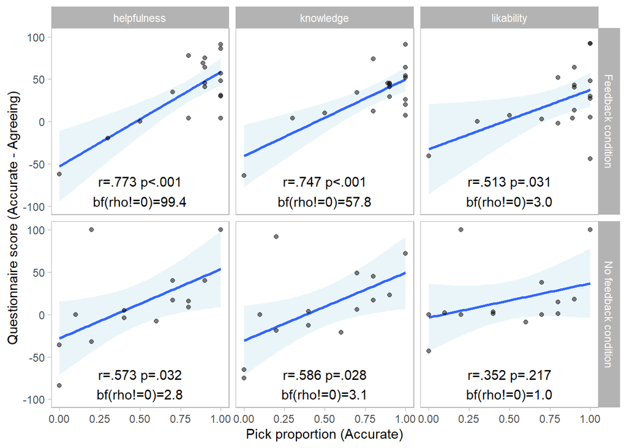

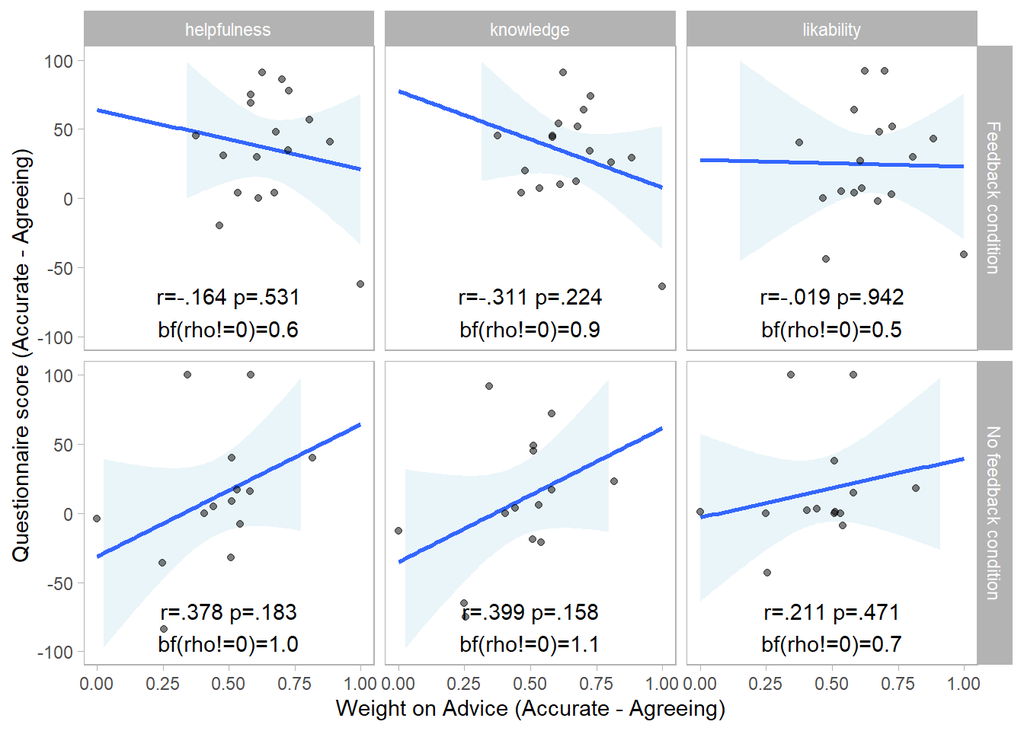

#### Summary

Participants in the Feedback condition showed a tendency to give higher ratings to the Accurate advisor, especially regarding helpfulness and knowledge. Those in the No feedback condition did not demonstrate especially systematic preferences, but it is probable that preferences were reasonably stable within individual participants across measures.

Overall, differences between advisors in participants’ ratings for all three questionnaire items were correlated with the extent to which they picked the higher rated advisor. This pattern was not shown significantly for influence, although the evidence was equivocal rather than indicative of equivalence. The pattern was shown most strongly for picking by participants in the Feedback condition.

### Debrief comments

| pid | condition | acc | agr | comment |
| --- | --- | --- | --- | --- |
| d28d0cf1 | Nofeedback.AgreeFirst | Advisor #35 | Advisor #11 | It seems to me that one advisor was better on the strict knowledge and another in the humanities, |
| 27958e21 | Feedback.AccurateFirst | Advisor #48 | Advisor #30 | I reckon one of the advisors was guessing and one was quite knowledgeable about all subject matter |
| 1da43186 | Nofeedback.AccurateFirst | Advisor #40 | Advisor #57 | One was really misleading, but the other one had more knowledge. |
| 7e145756 | Nofeedback.AgreeFirst | Advisor #14 | Advisor #53 | the green one was wrong more often? |
| dac2303f | Feedback.AccurateFirst | Advisor #20 | Advisor #38 | One advisor tended to suggest a date earlier than the answer but the other suggested dates later than the answer. |
| 14876975 | Nofeedback.AgreeFirst | Advisor #12 | Advisor #15 | I felt like the blue one was agreeing with me to just for the sake, and not actually being helpful |
| b71443ec | Nofeedback.AccurateFirst | Advisor #54 | Advisor #46 | I honestly didn’t notice anything. I felt that both of them used the same sized marker, and usually the answers they gave made sense with my very limited knowledge of history. I’m now very curious wha… |
| 4220d240 | Feedback.AgreeFirst | Advisor #21 | Advisor #50 | I think the purpose of the first advisor is to makes us put the incorrect response. The second one was very accurate |
| a7e5a5a0 | Nofeedback.AgreeFirst | Advisor #44 | Advisor #38 | The only difference I was able to notice was that one had more knowledge than the other. |
| e122a594 | Feedback.AgreeFirst | Advisor #41 | Advisor #14 | Number 41 was slightly more accurate/knowledgeable. |
| 7d5019a2 | Feedback.AgreeFirst | Advisor #17 | Advisor #32 | No idea. |
| afe89ea6 | Feedback.AgreeFirst | Advisor #40 | Advisor #35 | no |
| 2f33fcdb | Feedback.AgreeFirst | Advisor #44 | Advisor #34 | One advisor’s answers didn’t help much while the other advisor was quite helpful with the year rages. |
| e1440076 | Nofeedback.AccurateFirst | Advisor #23 | Advisor #19 | Blue was knowledgeable. Pink was unaware of the answer, always giving like guesses. |
| 4a4855b8 | Feedback.AccurateFirst | Advisor #31 | Advisor #38 | one advisor knew more answers correctly had maybe studies history or something like that the other was more following my answers |
| 576d1cb4 | Nofeedback.AgreeFirst | Advisor #53 | Advisor #50 | Not sure but I think the purple one was a bit better. |
| 44556cc3 | Feedback.AccurateFirst | Advisor #14 | Advisor #25 | Yes, there was a big difference. Adviser 14 knew more correct answers, than adviser 25 |
| a510d5b5 | Feedback.AccurateFirst | Advisor #40 | Advisor #46 | Advisor #40 was far more helpful |
| 9db5cf19 | Feedback.AgreeFirst | Advisor #17 | Advisor #12 | I’m assuming one of them was an actual person and the others answers were likely picked by the people running the survey. |
| 492db251 | Feedback.AccurateFirst | Advisor #26 | Advisor #49 | One had a pixelated smiley face |
| 27257cdf | Nofeedback.AgreeFirst | Advisor #39 | Advisor #49 | Accuracy of answers? |
| f29963f0 | Nofeedback.AccurateFirst | Advisor #22 | Advisor #12 | i think that the advisor no 12 was less accurate |
| ebb3c02f | Feedback.AccurateFirst | Advisor #25 | Advisor #35 | He was not very helpful. |
| ebb3c02f | Feedback.AccurateFirst | Advisor #25 | Advisor #35 | He was not very helpful. |
| 063a8b55 | Nofeedback.AccurateFirst | Advisor #59 | Advisor #54 | In my opinion one of the advisors was following the pattern of making customer happy about their choices, not neccesary giving good answers. The other one was quite good in giving advices. |
| 0dae2ffe | Nofeedback.AgreeFirst | Advisor #39 | Advisor #16 | I could not determine a difference. |
| 7f1d2e82 | Feedback.AccurateFirst | Advisor #10 | Advisor #50 | Maybe an age difference |
| 49a68296 | Feedback.AgreeFirst | Advisor #19 | Advisor #41 | I think one advisor agreed with a lot of my own answers even if they were totally wrong. And maybe there was a knowledge difference in the advisors. |
| cda81742 | Feedback.AccurateFirst | Advisor #11 | Advisor #59 | The green one was more knowledgable |
| 074411dc | Feedback.AgreeFirst | Advisor #14 | Advisor #40 | I think the green one was more accurate and helpful. Would suggest which direction I should move in. |
| 07b7eb07 | Nofeedback.AccurateFirst | Advisor #35 | Advisor #36 | i have no idea |
| eddaf357 | Nofeedback.AccurateFirst | Advisor #33 | Advisor #49 | One seemingly gave more wrong answers, the other seemed to be mostly right. |
| 94106dce | Feedback.AccurateFirst | Advisor #48 | Advisor #36 | One had more random answers than the other. |

### Picking likelihood analysis

We can define some pretty good, clearly distinct models of how participants’ pick proportions will look under a null model vs a preference model. The null model quite simply states that any preference in any direction of any strength is equally probable. Participants are known to vary in both their strength and direction of preference, so this model captures that intuition quite well. The preference model is agnostic as to strength of the preference, but places 95% of its area over the prefer Accurate side (allowing for ~5% of participants to make weird choices).

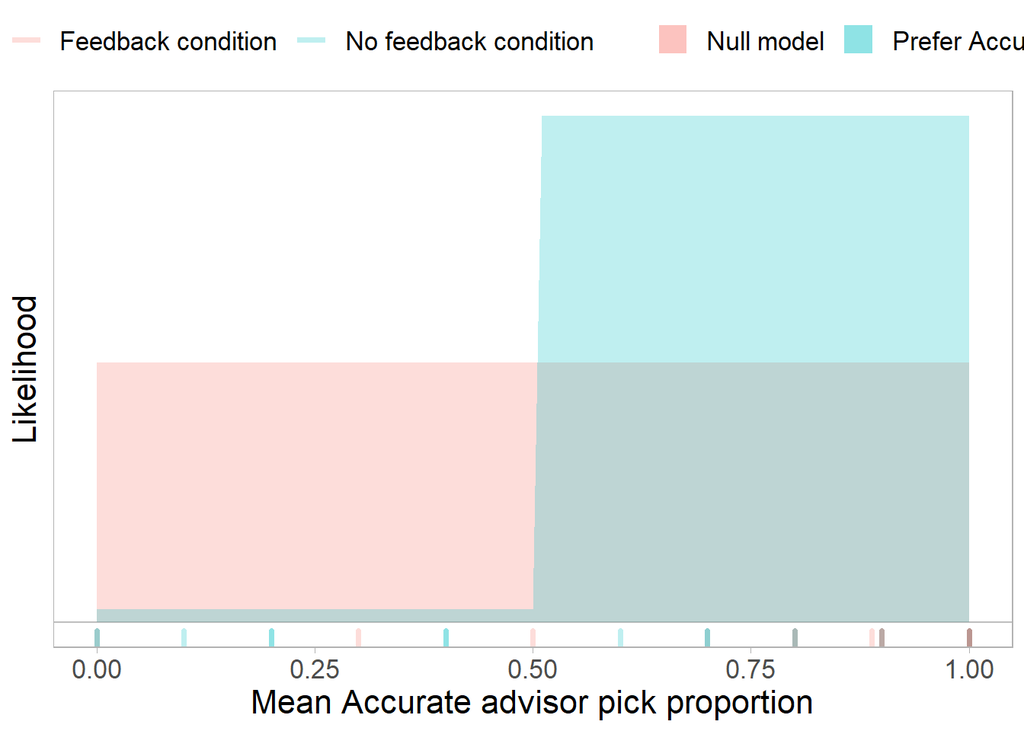

| FeedbackCondition | LRatio_pAcc_h0 | LRatio_pAgr_h0 | LRatio_pAcc_pAgr |
| --- | --- | --- | --- |
| Feedback condition | 2.801749e+00 | 2.262841e-19 | 1.238155e+19 |
| No feedback condition | 8.375917e-08 | 8.375917e-08 | 1.000000e+00 |

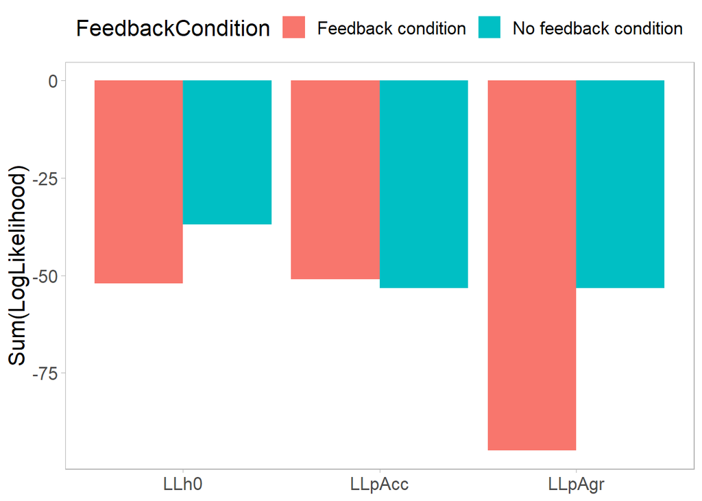

# Conclusions

As with the previous experiment, a preference was clear in the picking data for the participants in the Feedback condition: they appeared to learn about the differences in the advisors and to use that to identify and then select the Accurate advisor. Participants in the No feedback condition showed no systematic preference, and their data are consistent with a model wherein individual preferences are not systematically altered by experience. Participants in the No feedback condition did show a systematic relationship between how much advice they took from an advisor and the extent to which they picked that advisor, although it is not known whether the relationship is learned or based on an initial preference which is not updated.

# Credits

## Acknowledgements

Thanks as always to Nick Yeung and the other folks at the [ACC Lab](https://www.psy.ox.ac.uk/research/attention-cognitive-control-lab).

## R Packages

| Package | Citations |
| --- | --- |
| base | R Core Team (2018). R: A language and environment for statistical computing. R Foundation for Statistical Computing, Vienna, Austria. URL https://www.R-project.org/. |
| beepr | Rasmus Bååth (2018). beepr: Easily Play Notification Sounds on any Platform. R package version 1.3. https://CRAN.R-project.org/package=beepr |
| curl | Jeroen Ooms (2019). curl: A Modern and Flexible Web Client for R. R package version 4.0. https://CRAN.R-project.org/package=curl |
| testthat | Hadley Wickham. testthat: Get Started with Testing. The R Journal, vol. 3, no. 1, pp. 5--10, 2011 |
| Hmisc | Frank E Harrell Jr, with contributions from Charles Dupont and many others. (2019). Hmisc: Harrell Miscellaneous. R package version 4.2-0. https://CRAN.R-project.org/package=Hmisc |
| Formula | Achim Zeileis, Yves Croissant (2010). Extended Model Formulas in R: Multiple Parts and Multiple Responses. Journal of Statistical Software 34(1), 1-13. doi:10.18637/jss.v034.i01 |
| survival |  |
| lattice | Sarkar, Deepayan (2008) Lattice: Multivariate Data Visualization with R. Springer, New York. ISBN 978-0-387-75968-5 |
| ez | Michael A. Lawrence (2016). ez: Easy Analysis and Visualization of Factorial Experiments. R package version 4.4-0. https://CRAN.R-project.org/package=ez |
| knitr | Yihui Xie (2019). knitr: A General-Purpose Package for Dynamic Report Generation in R. R package version 1.24.Yihui Xie (2015) Dynamic Documents with R and knitr. 2nd edition. Chapman and Hall/CRC. IS… |

[output cut: 15 more lines]

## Funding

Matt Jaquiery is funded by a studentship from the [Medical Research Council](https://mrc.ukri.org/) (reference 1943590) and the University of Oxford [Department of Experimental Psychology](https://www.psy.ox.ac.uk/) (reference 17/18_MSD_661552).